# ARTI 404 - Image Processing

## Lab 4: Intensity Transformations and Filtering (Spatial Domain)

### Student 2240009025 Nawaf Rabea Shahbal

## Task 1: Thresholding

Thresholding turns a grayscale image into a binary image. Pixels above the threshold become white (255) and pixels below it become black (0). I will try 5 different threshold values and compare them.

```python
import cv2
import os
import numpy as np
import matplotlib.pyplot as plt
from skimage import data, img_as_float, exposure, io
```

I don't have Parrot.png so I used the `camera` image from skimage and saved it in an `images` folder. Then I load it in grayscale with OpenCV like the manual says.

```python
os.makedirs('images', exist_ok=True)
io.imsave('images/Parrot.png', data.camera(), check_contrast=False)

# Load the image in grayscale
img = cv2.imread('images/Parrot.png', cv2.IMREAD_GRAYSCALE)
print(img.shape, img.dtype)
```

```
(512, 512) uint8
```

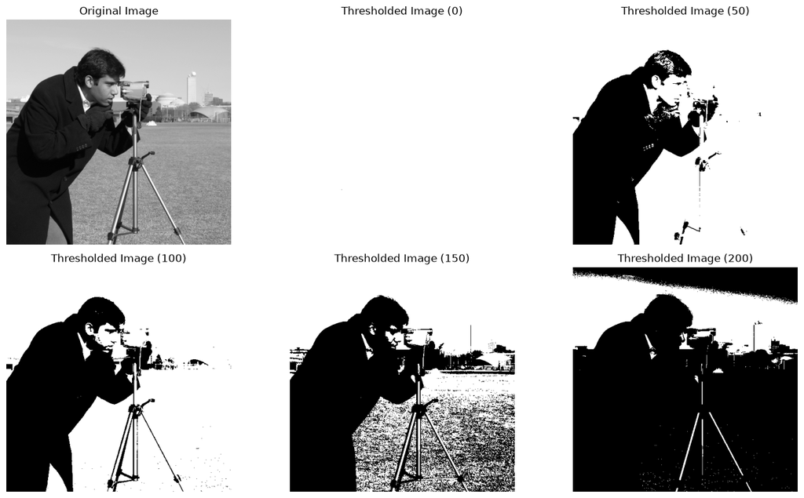

```python
# Set the threshold values
threshold_values = [0, 50, 100, 150, 200]

plt.figure(figsize=(14, 8))
plt.subplot(2, 3, 1)
plt.imshow(img, cmap='gray')
plt.title('Original Image')
plt.axis('off')

# Apply thresholding with different threshold values
for i, threshold_value in enumerate(threshold_values):
    ret, thresh = cv2.threshold(img, threshold_value, 255, cv2.THRESH_BINARY)
    plt.subplot(2, 3, i + 2)
    plt.imshow(thresh, cmap='gray')
    plt.title(f'Thresholded Image ({threshold_value})')
    plt.axis('off')
plt.tight_layout()
plt.show()
```

## Task 2: Histogram Processing

### Step 1: Load libraries

```python
import matplotlib
import matplotlib.pyplot as plt
import numpy as np
from skimage import data, img_as_float
from skimage import exposure
```

### Step 2: Load moon image

```python
img = data.moon()
print(img.shape, img.dtype, img.min(), img.max())
```

```
(512, 512) uint8 0 255
```

### Step 3: Contrast stretching (2nd and 98th percentiles)

```python
# Contrast stretching
p2, p98 = np.percentile(img, (2, 98))
img_rescale = exposure.rescale_intensity(img, in_range=(p2, p98))
print(p2, p98)
```

```
78.0 129.0
```

### Step 4: Display the images with their histograms

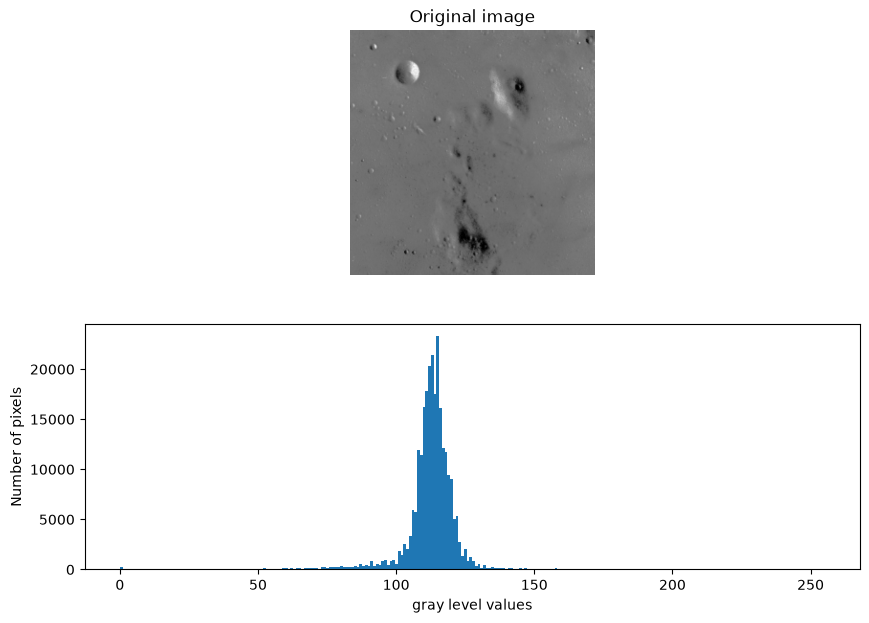

```python
fig = plt.figure(figsize=(10, 7))
fig.add_subplot(2, 1, 1)
plt.imshow(img, cmap='gray')
plt.axis('off')
plt.title('Original image')
fig.add_subplot(2, 1, 2)
plt.hist(img.flat, bins=256, range=(0, 255))
plt.xlabel('gray level values')
plt.ylabel('Number of pixels')
plt.show()
```

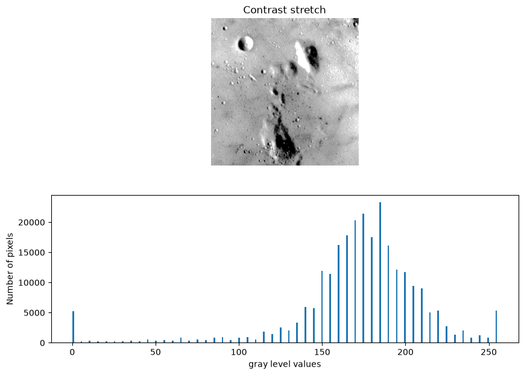

```python
fig = plt.figure(figsize=(10, 7))
fig.add_subplot(2, 1, 1)
plt.imshow(img_rescale, cmap='gray')
plt.axis('off')
plt.title('Contrast stretch')
fig.add_subplot(2, 1, 2)
plt.hist(img_rescale.flat, bins=256, range=(0, 255))
plt.xlabel('gray level values')
plt.ylabel('Number of pixels')
plt.show()
```

## Assessment

### Task 1: Rescale intensity using the 3rd and 80th percentiles

```
87.0 118.0
```

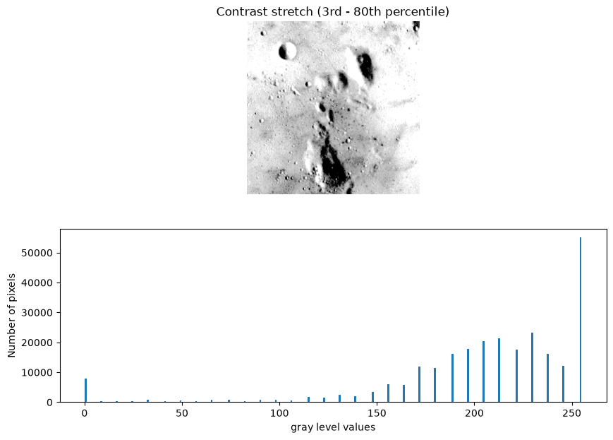

```python
p3, p80 = np.percentile(img, (3, 80))
img_rescale2 = exposure.rescale_intensity(img, in_range=(p3, p80))
print(p3, p80)

fig = plt.figure(figsize=(10, 7))
fig.add_subplot(2, 1, 1)
plt.imshow(img_rescale2, cmap='gray')
plt.axis('off')
plt.title('Contrast stretch (3rd - 80th percentile)')
fig.add_subplot(2, 1, 2)
plt.hist(img_rescale2.flat, bins=256, range=(0, 255))
plt.xlabel('gray level values')
plt.ylabel('Number of pixels')
plt.show()
```

**Observation:** Using the 80th percentile as the upper limit makes more of the bright pixels saturate to 255, so the image becomes brighter and there is a big spike at white in the histogram.

### Task 2: Histogram equalization (`exposure.equalize_hist`)

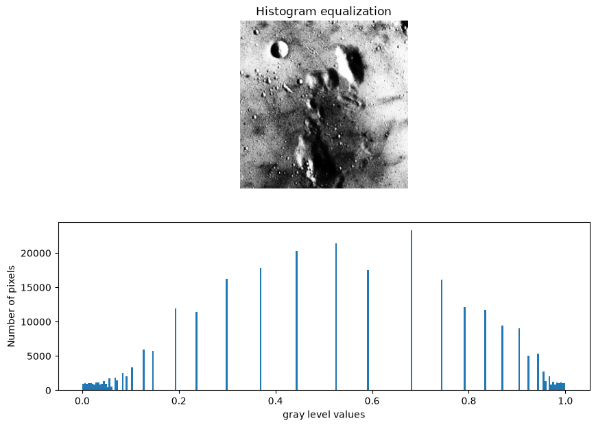

```python
img_eq = exposure.equalize_hist(img)   # output is float in range [0, 1]

fig = plt.figure(figsize=(10, 7))
fig.add_subplot(2, 1, 1)
plt.imshow(img_eq, cmap='gray')
plt.axis('off')
plt.title('Histogram equalization')
fig.add_subplot(2, 1, 2)
plt.hist(img_eq.flat, bins=256, range=(0, 1))
plt.xlabel('gray level values')
plt.ylabel('Number of pixels')
plt.show()
```

**Observation:** `equalize_hist` returns a float image between 0 and 1, so the histogram range is (0, 1). The histogram is now flatter (more uniform), The image has strong contrast.

### Task 3: Histogram matching (rocket as reference, Chelsea as the image)

```
(427, 640, 3) (300, 451, 3)
```

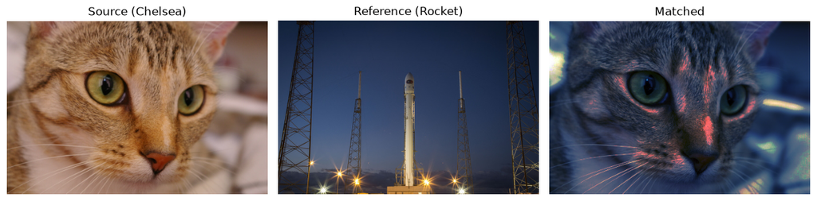

```python
reference = data.rocket()
image = data.chelsea()
print(reference.shape, image.shape)

# channel_axis=-1 because the images are RGB
matched = exposure.match_histograms(image, reference, channel_axis=-1)

fig, (ax1, ax2, ax3) = plt.subplots(nrows=1, ncols=3, figsize=(12, 4))
for aa in (ax1, ax2, ax3):
    aa.set_axis_off()

ax1.imshow(image)
ax1.set_title('Source (Chelsea)')
ax2.imshow(reference)
ax2.set_title('Reference (Rocket)')
ax3.imshow(matched)
ax3.set_title('Matched')
plt.tight_layout()
plt.show()
```

Now I plot the histogram of each channel (R, G, B) for the three images to check the matching.

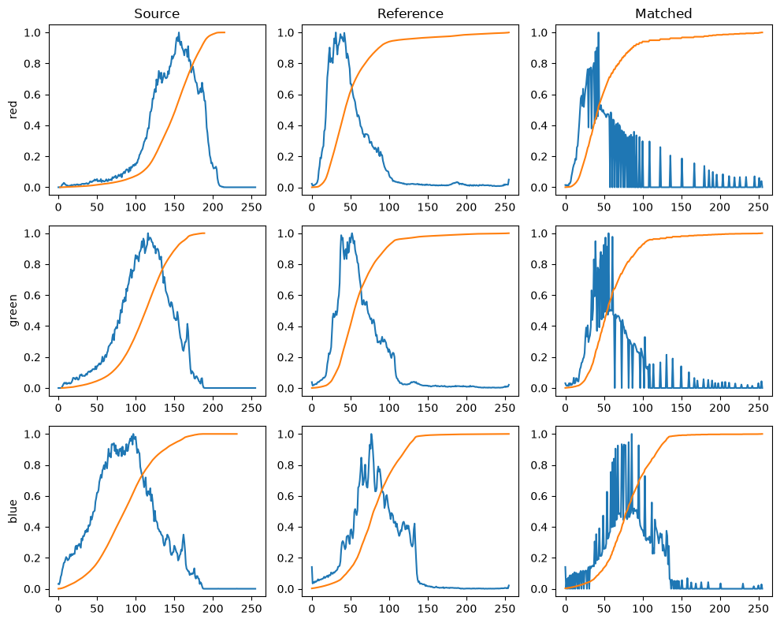

```python
fig, axes = plt.subplots(nrows=3, ncols=3, figsize=(10, 8))

for i, img_ in enumerate((image, reference, matched)):
    for c, c_color in enumerate(('red', 'green', 'blue')):
        img_hist, bins = exposure.histogram(img_[..., c], source_range='dtype')
        axes[c, i].plot(bins, img_hist / img_hist.max())
        img_cdf, bins = exposure.cumulative_distribution(img_[..., c])
        axes[c, i].plot(bins, img_cdf)
        axes[c, 0].set_ylabel(c_color)

axes[0, 0].set_title('Source')
axes[0, 1].set_title('Reference')
axes[0, 2].set_title('Matched')
plt.tight_layout()
plt.show()
```

**Observation:** After matching, the cat image takes the color distribution of the rocket image.

## Conclusion

In this lab I used thresholding, contrast stretching, histogram equalization and histogram matching.